# Team file

Andres Gonzalez, Evan behrens, Brandon Simelgor

2023-03-02

```r
choco <- read.csv("https://ds202-at-isu.github.io/labs/data/choco.csv")
head(choco)
```

```
##    Company Specific.Bean.Origin  REF Review.Date Cocoa.Pct Company.Location
## 1 A. Morin          Agua Grande 1876        2016        63           France
## 2 A. Morin                Kpime 1676        2015        70           France
## 3 A. Morin               Panama 1011        2013        70           France
## 4 A. Morin           Madagascar 1011        2013        70           France
## 5 A. Morin               Brazil 1011        2013        70           France
## 6 A. Morin             Equateur 1011        2013        70           France
##   Rating Bean.Type Broad.Bean.Origin
## 1   3.75                    Sao Tome
## 2   2.75                        Togo
## 3   2.75                      Panama
## 4   3.00   Criollo        Madagascar
## 5   3.25                      Brazil
## 6   3.75                     Ecuador
```

```r
str(choco)
```

```
## 'data.frame':    1852 obs. of  9 variables:
##  $ Company             : chr  "A. Morin" "A. Morin" "A. Morin" "A. Morin" ...
##  $ Specific.Bean.Origin: chr  "Agua Grande" "Kpime" "Panama" "Madagascar" ...
##  $ REF                 : int  1876 1676 1011 1011 1011 1011 1015 1015 1015 1015 ...
##  $ Review.Date         : int  2016 2015 2013 2013 2013 2013 2013 2013 2013 2013 ...
##  $ Cocoa.Pct           : num  63 70 70 70 70 70 70 70 70 70 ...
##  $ Company.Location    : chr  "France" "France" "France" "France" ...
##  $ Rating              : num  3.75 2.75 2.75 3 3.25 3.75 2.75 3 3.25 4 ...
##  $ Bean.Type           : chr  "" "" "" "Criollo" ...
##  $ Broad.Bean.Origin   : chr  "Sao Tome" "Togo" "Panama" "Madagascar" ...
```

```r
library(tidyverse)
```

```r
library(ggplot2)
```

# Andres Question

My question was which broad bean origin had the highest ratings? From my barplot, I found that Venezuela had the most highest ratings with 20 “4” ratings. When making this analysis I decided to just look at the top rated chocolates so I only looked at data entries that had a 4.0 rating.

```r
choco_filtered <- choco %>% filter(Rating==4)
head(choco_filtered)
```

```
##    Company              Specific.Bean.Origin  REF Review.Date Cocoa.Pct
## 1 A. Morin                             Chuao 1015        2013        70
## 2 A. Morin              Chanchamayo Province 1019        2013        63
## 3 A. Morin                           Pablino 1319        2014        70
## 4     AMMA Monte Alegre, 3 diff. plantations  572        2010        60
## 5    Amano                            Morobe  725        2011        70
## 6    Amano                            Guayas  470        2010        70
##   Company.Location Rating             Bean.Type Broad.Bean.Origin
## 1           France      4            Trinitario         Venezuela
## 2           France      4                                    Peru
## 3           France      4                                    Peru
## 4           Brazil      4 Forastero (Parazinho)            Brazil
## 5           U.S.A.      4                        Papua New Guinea
## 6           U.S.A.      4                                 Ecuador
```

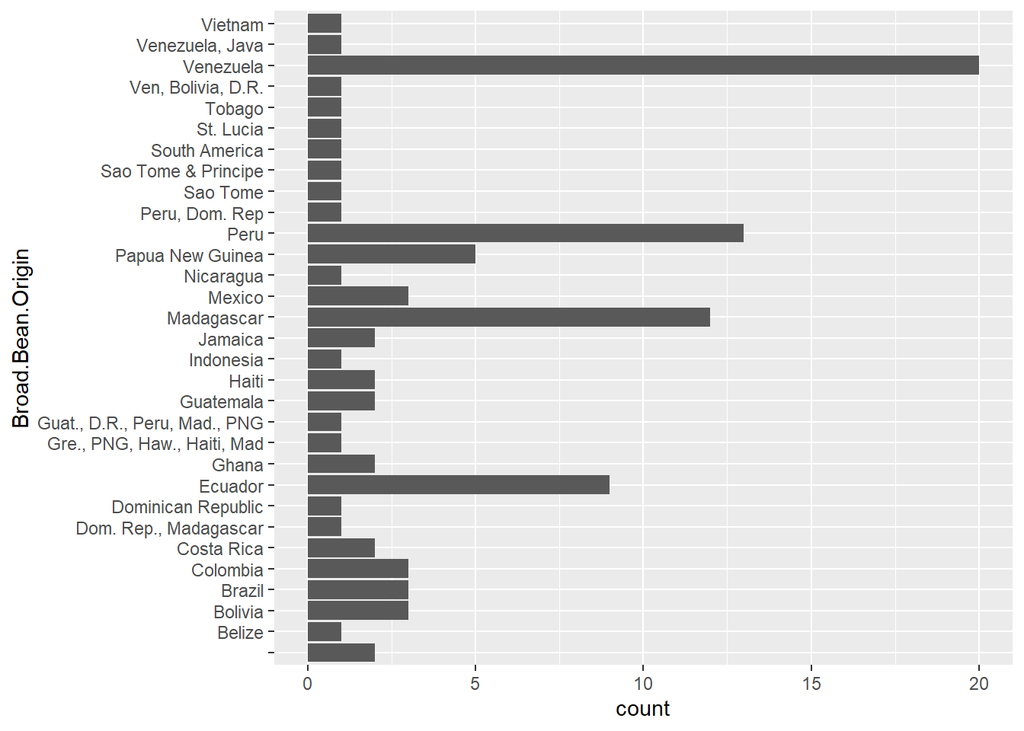

```r
ggplot(choco_filtered, aes(y = Broad.Bean.Origin)) + geom_bar()
```

# Evan’s Question

What was the most common cocoa percentage in a 4 rating?

I found that the most common percentage of cocoa used in chocolates rated 4 was right around 70. There are outliers at 60 and 90

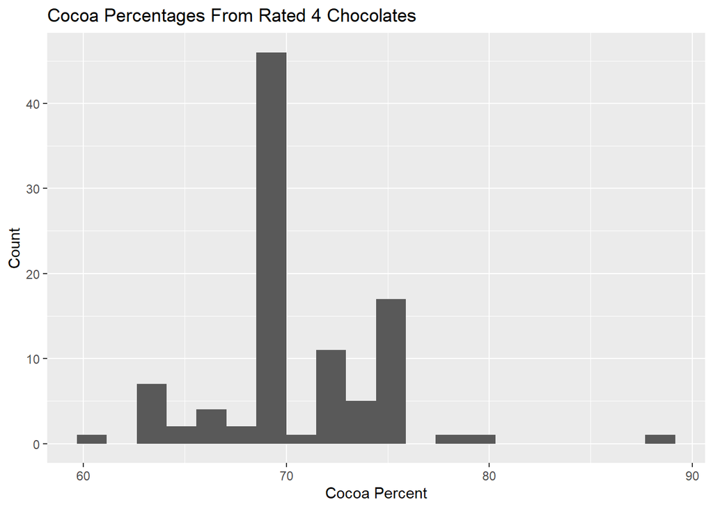

```r
ggplot(choco_filtered, aes(x = Cocoa.Pct)) +
  geom_histogram(bins = 20) +xlab("Cocoa Percent") +ylab("Count") +ggtitle("Cocoa Percentages From Rated 4 Chocolates")
```

# Brandon’s Question

Which company most commonly recieved a 4 rating?

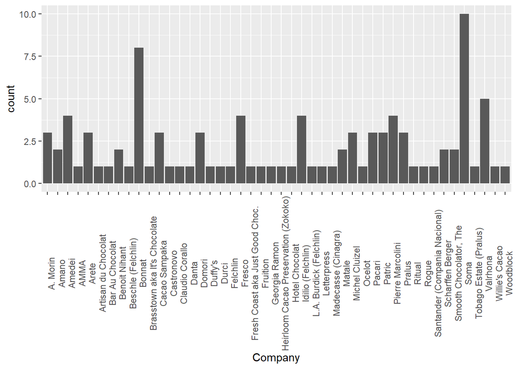

```r
ggplot(choco_filtered, aes(x = Company)) + geom_bar() + theme (axis.text.x = element_text(angle = 90))
```

# Conclusion

The workflow was very smooth. All of us were able to come up with our own questions and answer them using graphs, ggplot and filter out certain data. We used to git and were able to pull and push our data whenever one of us edited the document. we all uploaded our own work into the repository without issue. The workflow was smooth the whole time.